```python
import pandas as pd
import matplotlib.pyplot as plt
```

# Data Processing

importing and reading data stored in dataset-financial analytics data.csv

```python
dataFrame = pd.read_csv("Financial Analytics data.csv")
```

Printing columns names

```python
dataFrame.columns
```

```
Index(['S.No.', 'Name', 'Mar Cap - Crore', 'Sales Qtr - Crore', 'Unnamed: 4'], dtype='object')
```

```python
dataFrame.shape
```

```
(488, 5)
```

Printing precise summary of our csv

```python
dataFrame.info()
```

```
<class 'pandas.core.frame.DataFrame'>
RangeIndex: 488 entries, 0 to 487
Data columns (total 5 columns):
 #   Column             Non-Null Count  Dtype
---  ------             --------------  -----
 0   S.No.              488 non-null    int64
 1   Name               488 non-null    object
 2   Mar Cap - Crore    479 non-null    float64
 3   Sales Qtr - Crore  365 non-null    float64
 4   Unnamed: 4         94 non-null     float64
dtypes: float64(3), int64(1), object(1)
memory usage: 19.2+ KB
```

```python
dataFrame
```

|  | S.No. | Name | Mar Cap - Crore | Sales Qtr - Crore | Unnamed: 4 |
| --- | --- | --- | --- | --- | --- |
| 0 | 1 | Reliance Inds. | 583436.72 | 99810.00 | NaN |
| 1 | 2 | TCS | 563709.84 | 30904.00 | NaN |
| 2 | 3 | HDFC Bank | 482953.59 | 20581.27 | NaN |
| 3 | 4 | ITC | 320985.27 | 9772.02 | NaN |
| 4 | 5 | H D F C | 289497.37 | 16840.51 | NaN |
| ... | ... | ... | ... | ... | ... |
| 483 | 496 | Lak. Vilas Bank | 3029.57 | 790.17 | NaN |
| 484 | 497 | NOCIL | 3026.26 | 249.27 | NaN |
| 485 | 498 | Orient Cement | 3024.32 | 511.53 | NaN |
| 486 | 499 | Natl.Fertilizer | 3017.07 | 2840.75 | NaN |
| 487 | 500 | L T Foods | NaN | NaN | NaN |

488 rows × 5 columns

```python
dataFrame.head(10)
```

|  | S.No. | Name | Mar Cap - Crore | Sales Qtr - Crore | Unnamed: 4 |
| --- | --- | --- | --- | --- | --- |
| 0 | 1 | Reliance Inds. | 583436.72 | 99810.00 | NaN |
| 1 | 2 | TCS | 563709.84 | 30904.00 | NaN |
| 2 | 3 | HDFC Bank | 482953.59 | 20581.27 | NaN |
| 3 | 4 | ITC | 320985.27 | 9772.02 | NaN |
| 4 | 5 | H D F C | 289497.37 | 16840.51 | NaN |
| 5 | 6 | Hind. Unilever | 288265.26 | 8590.00 | NaN |
| 6 | 7 | Maruti Suzuki | 263493.81 | 19283.20 | NaN |
| 7 | 8 | Infosys | 248320.35 | 17794.00 | NaN |
| 8 | 9 | O N G C | 239981.50 | 22995.88 | NaN |
| 9 | 10 | St Bk of India | 232763.33 | 57014.08 | NaN |

```python
dataFrame.tail(10)
```

|  | S.No. | Name | Mar Cap - Crore | Sales Qtr - Crore | Unnamed: 4 |
| --- | --- | --- | --- | --- | --- |
| 478 | 491 | Kaveri Seed Co. | 3125.83 | 70.64 | NaN |
| 479 | 492 | Star Ferro Cem. | 3115.98 | 393.49 | NaN |
| 480 | 493 | Deepak Fert. | 3079.06 | 1644.92 | NaN |
| 481 | 494 | Va Tech Wabag | 3041.93 | 460.89 | NaN |
| 482 | 495 | Prime Focus | 3031.50 | 609.61 | NaN |
| 483 | 496 | Lak. Vilas Bank | 3029.57 | 790.17 | NaN |
| 484 | 497 | NOCIL | 3026.26 | 249.27 | NaN |
| 485 | 498 | Orient Cement | 3024.32 | 511.53 | NaN |
| 486 | 499 | Natl.Fertilizer | 3017.07 | 2840.75 | NaN |
| 487 | 500 | L T Foods | NaN | NaN | NaN |

```python
dataFrame.describe()
```

|  | S.No. | Mar Cap - Crore | Sales Qtr - Crore | Unnamed: 4 |
| --- | --- | --- | --- | --- |
| count | 488.000000 | 479.000000 | 365.000000 | 94.000000 |
| mean | 251.508197 | 28043.857119 | 4395.976849 | 1523.870106 |
| std | 145.884078 | 59464.615831 | 11092.206185 | 1800.008836 |
| min | 1.000000 | 3017.070000 | 47.240000 | 0.000000 |
| 25% | 122.750000 | 4843.575000 | 593.740000 | 407.167500 |
| 50% | 252.500000 | 9885.050000 | 1278.300000 | 702.325000 |
| 75% | 378.250000 | 23549.900000 | 2840.750000 | 2234.815000 |
| max | 500.000000 | 583436.720000 | 110666.930000 | 7757.060000 |

# Data Cleaning

Printing null values of each column

```python
print(f"Null values:")
print(f"[S.No.] = {dataFrame['S.No.'].isnull().sum()}")
print(f"[Name] = {dataFrame['Name'].isnull().sum()}")
print(f"[Mar Cap - Crore] = {dataFrame['Mar Cap - Crore'].isnull().sum()}")
print(f"[Sales Qtr - Crore] = {dataFrame['Sales Qtr - Crore'].isnull().sum()}")
print(f"[Unnamed: 4] = {dataFrame['Unnamed: 4'].isnull().sum()}")
```

```
Null values:
[S.No.] = 0
[Name] = 0
[Mar Cap - Crore] = 9
[Sales Qtr - Crore] = 123
[Unnamed: 4] = 394
```

```python
dataFrame.columns = ['S.No.', 'Name of Company', 'Market Cap (in Cr)', 'Quaterly Sales (in Cr)', 'temp-unnamed']
```

```python
dataFrame
```

|  | S.No. | Name of Company | Market Cap (in Cr) | Quaterly Sales (in Cr) | temp-unnamed |
| --- | --- | --- | --- | --- | --- |
| 0 | 1 | Reliance Inds. | 583436.72 | 99810.00 | NaN |
| 1 | 2 | TCS | 563709.84 | 30904.00 | NaN |
| 2 | 3 | HDFC Bank | 482953.59 | 20581.27 | NaN |
| 3 | 4 | ITC | 320985.27 | 9772.02 | NaN |
| 4 | 5 | H D F C | 289497.37 | 16840.51 | NaN |
| ... | ... | ... | ... | ... | ... |
| 483 | 496 | Lak. Vilas Bank | 3029.57 | 790.17 | NaN |
| 484 | 497 | NOCIL | 3026.26 | 249.27 | NaN |
| 485 | 498 | Orient Cement | 3024.32 | 511.53 | NaN |
| 486 | 499 | Natl.Fertilizer | 3017.07 | 2840.75 | NaN |
| 487 | 500 | L T Foods | NaN | NaN | NaN |

488 rows × 5 columns

```python
max_serial_number = dataFrame['S.No.'].max()
all_numbers = set(range(1, max_serial_number + 1))
```

```python
present_numbers = set(dataFrame['S.No.'])
```

```python
missing_numbers = all_numbers - present_numbers
```

```python
print("Numbers not present in ['S.No.'] column:", missing_numbers)
```

```
Numbers not present in ['S.No.'] column: {265, 266, 174, 175, 251, 188, 252, 253, 187, 124, 125, 254}
```

```python
dataFrame
```

|  | S.No. | Name of Company | Market Cap (in Cr) | Quaterly Sales (in Cr) | temp-unnamed |
| --- | --- | --- | --- | --- | --- |
| 0 | 1 | Reliance Inds. | 583436.72 | 99810.00 | NaN |
| 1 | 2 | TCS | 563709.84 | 30904.00 | NaN |
| 2 | 3 | HDFC Bank | 482953.59 | 20581.27 | NaN |
| 3 | 4 | ITC | 320985.27 | 9772.02 | NaN |
| 4 | 5 | H D F C | 289497.37 | 16840.51 | NaN |
| ... | ... | ... | ... | ... | ... |
| 483 | 496 | Lak. Vilas Bank | 3029.57 | 790.17 | NaN |
| 484 | 497 | NOCIL | 3026.26 | 249.27 | NaN |
| 485 | 498 | Orient Cement | 3024.32 | 511.53 | NaN |
| 486 | 499 | Natl.Fertilizer | 3017.07 | 2840.75 | NaN |
| 487 | 500 | L T Foods | NaN | NaN | NaN |

488 rows × 5 columns

```python
#reset display options to default values

# pd.reset_option('display.max_rows')
# pd.reset_option('display.max_columns')
```

```python
for i in range(len(dataFrame)):
    if pd.isnull(dataFrame['temp-unnamed'][i]):
        pass
    else:
        #dataFrame['Sales Qtr - Crore'][i] = dataFrame['temp-unnamed'][i]
        dataFrame.loc[i, 'Quaterly Sales (in Cr)'] = dataFrame['temp-unnamed'][i]
```

```python
dataFrame
```

|  | S.No. | Name of Company | Market Cap (in Cr) | Quaterly Sales (in Cr) | temp-unnamed |
| --- | --- | --- | --- | --- | --- |
| 0 | 1 | Reliance Inds. | 583436.72 | 99810.00 | NaN |
| 1 | 2 | TCS | 563709.84 | 30904.00 | NaN |
| 2 | 3 | HDFC Bank | 482953.59 | 20581.27 | NaN |
| 3 | 4 | ITC | 320985.27 | 9772.02 | NaN |
| 4 | 5 | H D F C | 289497.37 | 16840.51 | NaN |
| ... | ... | ... | ... | ... | ... |
| 483 | 496 | Lak. Vilas Bank | 3029.57 | 790.17 | NaN |
| 484 | 497 | NOCIL | 3026.26 | 249.27 | NaN |
| 485 | 498 | Orient Cement | 3024.32 | 511.53 | NaN |
| 486 | 499 | Natl.Fertilizer | 3017.07 | 2840.75 | NaN |
| 487 | 500 | L T Foods | NaN | NaN | NaN |

488 rows × 5 columns

```python
del dataFrame['temp-unnamed']
```

```python
del dataFrame['S.No.']
```

```python
dataFrame
```

|  | Name of Company | Market Cap (in Cr) | Quaterly Sales (in Cr) |
| --- | --- | --- | --- |
| 0 | Reliance Inds. | 583436.72 | 99810.00 |
| 1 | TCS | 563709.84 | 30904.00 |
| 2 | HDFC Bank | 482953.59 | 20581.27 |
| 3 | ITC | 320985.27 | 9772.02 |
| 4 | H D F C | 289497.37 | 16840.51 |
| ... | ... | ... | ... |
| 483 | Lak. Vilas Bank | 3029.57 | 790.17 |
| 484 | NOCIL | 3026.26 | 249.27 |
| 485 | Orient Cement | 3024.32 | 511.53 |
| 486 | Natl.Fertilizer | 3017.07 | 2840.75 |
| 487 | L T Foods | NaN | NaN |

488 rows × 3 columns

```python
dataFrame.info()
```

```
<class 'pandas.core.frame.DataFrame'>
RangeIndex: 488 entries, 0 to 487
Data columns (total 3 columns):
 #   Column                  Non-Null Count  Dtype
---  ------                  --------------  -----
 0   Name of Company         488 non-null    object
 1   Market Cap (in Cr)      479 non-null    float64
 2   Quaterly Sales (in Cr)  459 non-null    float64
dtypes: float64(2), object(1)
memory usage: 11.6+ KB
```

```python
print(f"Null values:")
print(f"[Name of Company] = {dataFrame['Name of Company'].isnull().sum()}")
print(f"[Market Cap (in Cr)] = {dataFrame['Market Cap (in Cr)'].isnull().sum()}")
print(f"[Quaterly Sales (in Cr)] = {dataFrame['Quaterly Sales (in Cr)'].isnull().sum()}")
```

```
Null values:
[Name of Company] = 0
[Market Cap (in Cr)] = 9
[Quaterly Sales (in Cr)] = 29
```

```python
print(f"Median for ['Market Cap (in Cr)']: {dataFrame['Market Cap (in Cr)'].median()}")
print(f"Median for ['Quaterly Sales (in Cr)']: {dataFrame['Quaterly Sales (in Cr)'].median()}")
```

```
Median for ['Market Cap (in Cr)']: 9885.05
Median for ['Quaterly Sales (in Cr)']: 1137.17
```

```python
for i in range(len(dataFrame)):
    if pd.isnull(dataFrame['Market Cap (in Cr)'][i]):
        dataFrame.loc[i, 'Market Cap (in Cr)'] = dataFrame['Market Cap (in Cr)'].median()
```

```python
for i in range(len(dataFrame)):
    if pd.isnull(dataFrame['Quaterly Sales (in Cr)'][i]):
        dataFrame.loc[i, 'Quaterly Sales (in Cr)'] = dataFrame['Quaterly Sales (in Cr)'].median()
```

```python
dataFrame['Name of Company']
```

```
0       Reliance Inds.
1                  TCS
2            HDFC Bank
3                  ITC
4              H D F C
            ...
483    Lak. Vilas Bank
484              NOCIL
485      Orient Cement
486    Natl.Fertilizer
487          L T Foods
Name: Name of Company, Length: 488, dtype: object
```

```python
dataFrame
```

|  | Name of Company | Market Cap (in Cr) | Quaterly Sales (in Cr) |
| --- | --- | --- | --- |
| 0 | Reliance Inds. | 583436.72 | 99810.00 |
| 1 | TCS | 563709.84 | 30904.00 |
| 2 | HDFC Bank | 482953.59 | 20581.27 |
| 3 | ITC | 320985.27 | 9772.02 |
| 4 | H D F C | 289497.37 | 16840.51 |
| ... | ... | ... | ... |
| 483 | Lak. Vilas Bank | 3029.57 | 790.17 |
| 484 | NOCIL | 3026.26 | 249.27 |
| 485 | Orient Cement | 3024.32 | 511.53 |
| 486 | Natl.Fertilizer | 3017.07 | 2840.75 |
| 487 | L T Foods | 9885.05 | 1137.17 |

488 rows × 3 columns

```python
dataFrame.to_csv('Financial Analytics data.csv', index = False)
```

```python
dataFrame.describe().astype(int)
```

|  | Market Cap (in Cr) | Quaterly Sales (in Cr) |
| --- | --- | --- |
| count | 488 | 488 |
| mean | 27708 | 3649 |
| std | 58963 | 9708 |
| min | 3017 | 0 |
| 25% | 4879 | 570 |
| 50% | 9885 | 1137 |
| 75% | 23400 | 2580 |
| max | 583436 | 110666 |

```python
sorted_df = dataFrame.sort_values(by='Market Cap (in Cr)', ascending=False)
largest_mk_cap_comp = sorted_df
for i in range(10):
    print(f"Market Cap: {sorted_df.iloc[i]['Name of Company']}, {sorted_df.iloc[i]['Market Cap (in Cr)'].astype(int)} Cr")
```

```
Market Cap: Reliance Inds., 583436 Cr
Market Cap: TCS, 563709 Cr
Market Cap: HDFC Bank, 482953 Cr
Market Cap: ITC, 320985 Cr
Market Cap: H D F C, 289497 Cr
Market Cap: Hind. Unilever, 288265 Cr
Market Cap: Maruti Suzuki, 263493 Cr
Market Cap: Infosys, 248320 Cr
Market Cap: O N G C, 239981 Cr
Market Cap: St Bk of India, 232763 Cr
```

```python
sorted_df = dataFrame.sort_values(by='Market Cap (in Cr)', ascending=True)
print(f"Company: {sorted_df.iloc[0]['Name of Company']}")
print(f"Market cap: {sorted_df.iloc[0]['Market Cap (in Cr)'].astype(int)} Cr")
```

```
Company: Natl.Fertilizer
Market cap: 3017 Cr
```

```python
sorted_df = dataFrame.sort_values(by='Quaterly Sales (in Cr)', ascending=False)
print(f"Company: {sorted_df.iloc[0]['Name of Company']}")
print(f"Quaterly Sales: {sorted_df.iloc[0]['Quaterly Sales (in Cr)'].astype(int)} Cr")
```

```
Company: I O C L
Quaterly Sales: 110666 Cr
```

```python
sorted_df = dataFrame.sort_values(by='Quaterly Sales (in Cr)', ascending=True)
print(f"Company: {sorted_df.iloc[0]['Name of Company']}")
print(f"Quaterly Sales: {sorted_df.iloc[0]['Quaterly Sales (in Cr)'].astype(int)} Cr")
```

```
Company: Ujjivan Fin.Ser.
Quaterly Sales: 0 Cr
```

```python
sorted_df = dataFrame.sort_values(by='Market Cap (in Cr)', ascending=False)
largest_mk_cap_comp = sorted_df
for i in range(10):
    print(f"Market Cap: {sorted_df.iloc[i]['Name of Company']}, {sorted_df.iloc[i]['Market Cap (in Cr)'].astype(int)} Cr")
```

```
Market Cap: Reliance Inds., 583436 Cr
Market Cap: TCS, 563709 Cr
Market Cap: HDFC Bank, 482953 Cr
Market Cap: ITC, 320985 Cr
Market Cap: H D F C, 289497 Cr
Market Cap: Hind. Unilever, 288265 Cr
Market Cap: Maruti Suzuki, 263493 Cr
Market Cap: Infosys, 248320 Cr
Market Cap: O N G C, 239981 Cr
Market Cap: St Bk of India, 232763 Cr
```

```python
sorted_df = dataFrame.sort_values(by='Market Cap (in Cr)', ascending=True)
smallest_mk_cap_comp = sorted_df
for i in range(10):
    print(f"Market Cap: {sorted_df.iloc[i]['Name of Company']}, {sorted_df.iloc[i]['Market Cap (in Cr)'].astype(int)} Cr")
```

```
Market Cap: Natl.Fertilizer, 3017 Cr
Market Cap: Orient Cement, 3024 Cr
Market Cap: NOCIL, 3026 Cr
Market Cap: Lak. Vilas Bank, 3029 Cr
Market Cap: Prime Focus, 3031 Cr
Market Cap: Va Tech Wabag, 3041 Cr
Market Cap: Deepak Fert., 3079 Cr
Market Cap: Star Ferro Cem., 3115 Cr
Market Cap: Kaveri Seed Co., 3125 Cr
Market Cap: Firstsour.Solu., 3139 Cr
```

```python
sorted_df = dataFrame.sort_values(by='Quaterly Sales (in Cr)', ascending=False)
largest_qt_sales_comp = sorted_df
for i in range(10):
    print(f"Quaterly Sales: {sorted_df.iloc[i]['Name of Company']}, {sorted_df.iloc[i]['Quaterly Sales (in Cr)'].astype(int)} Cr")
```

```
Quaterly Sales: I O C L, 110666 Cr
Quaterly Sales: Reliance Inds., 99810 Cr
Quaterly Sales: Tata Motors, 74156 Cr
Quaterly Sales: B P C L, 60616 Cr
Quaterly Sales: H P C L, 57474 Cr
Quaterly Sales: St Bk of India, 57014 Cr
Quaterly Sales: Rajesh Exports, 41304 Cr
Quaterly Sales: Tata Steel, 32464 Cr
Quaterly Sales: TCS, 30904 Cr
Quaterly Sales: Larsen & Toubro, 28747 Cr
```

```python
sorted_df = dataFrame.sort_values(by='Quaterly Sales (in Cr)', ascending=True)
smallest_qt_sales_comp = sorted_df
for i in range(10):
    print(f"Quaterly Sales: {sorted_df.iloc[i]['Name of Company']}, {sorted_df.iloc[i]['Quaterly Sales (in Cr)'].astype(int)} Cr")
```

```
Quaterly Sales: Ujjivan Fin.Ser., 0 Cr
Quaterly Sales: SPARC, 19 Cr
Quaterly Sales: Tata Inv.Corpn., 47 Cr
Quaterly Sales: Central Dep. Ser, 47 Cr
Quaterly Sales: Multi Comm. Exc., 60 Cr
Quaterly Sales: Forbes & Co, 63 Cr
Quaterly Sales: Indian Energy Ex, 64 Cr
Quaterly Sales: La Opala RG, 69 Cr
Quaterly Sales: Kaveri Seed Co., 70 Cr
Quaterly Sales: CARE Ratings, 74 Cr
```

```python
dataFrame['Sales Efficiency Ratio'] = (dataFrame['Market Cap (in Cr)'] / dataFrame['Quaterly Sales (in Cr)']).round(2)
```

```python
dataFrame
```

|  | Name of Company | Market Cap (in Cr) | Quaterly Sales (in Cr) | Sales Efficiency Ratio |
| --- | --- | --- | --- | --- |
| 0 | Reliance Inds. | 583436.72 | 99810.00 | 5.85 |
| 1 | TCS | 563709.84 | 30904.00 | 18.24 |
| 2 | HDFC Bank | 482953.59 | 20581.27 | 23.47 |
| 3 | ITC | 320985.27 | 9772.02 | 32.85 |
| 4 | H D F C | 289497.37 | 16840.51 | 17.19 |
| ... | ... | ... | ... | ... |
| 483 | Lak. Vilas Bank | 3029.57 | 790.17 | 3.83 |
| 484 | NOCIL | 3026.26 | 249.27 | 12.14 |
| 485 | Orient Cement | 3024.32 | 511.53 | 5.91 |
| 486 | Natl.Fertilizer | 3017.07 | 2840.75 | 1.06 |
| 487 | L T Foods | 9885.05 | 1137.17 | 8.69 |

488 rows × 4 columns

```python
sorted_df = dataFrame.sort_values(by='Sales Efficiency Ratio', ascending=False)
largest_sales_eff_ratio_comp = sorted_df
for i in range(10):
    if sorted_df.iloc[i]['Sales Efficiency Ratio'] == 'inf':
        pass
    print(f"Sales Efficiency Ratio: {sorted_df.iloc[i]['Name of Company']}, {sorted_df.iloc[i]['Sales Efficiency Ratio'].astype(float)}")
```

```
Sales Efficiency Ratio: Ujjivan Fin.Ser., inf
Sales Efficiency Ratio: SPARC, 553.82
Sales Efficiency Ratio: Bajaj Holdings, 95.35
Sales Efficiency Ratio: Tata Inv.Corpn., 93.61
Sales Efficiency Ratio: Indian Energy Ex, 70.98
Sales Efficiency Ratio: Central Dep. Ser, 70.2
Sales Efficiency Ratio: Forbes & Co, 67.76
Sales Efficiency Ratio: Multi Comm. Exc., 63.1
Sales Efficiency Ratio: Delta Corp, 58.78
Sales Efficiency Ratio: ERIS Lifescience, 56.47
```

```python
sorted_df = dataFrame.sort_values(by='Sales Efficiency Ratio', ascending=True)
smallest_sales_eff_ratio_comp = sorted_df
for i in range(10):
    print(f"Sales Efficiency Ratio: {sorted_df.iloc[i]['Name of Company']}, {sorted_df.iloc[i]['Sales Efficiency Ratio'].astype(float)}")
```

```
Sales Efficiency Ratio: Redington India, 0.5
Sales Efficiency Ratio: Rajesh Exports, 0.57
Sales Efficiency Ratio: C P C L, 0.63
Sales Efficiency Ratio: Corporation Bank, 0.85
Sales Efficiency Ratio: Oriental Bank, 0.86
Sales Efficiency Ratio: Andhra Bank, 0.89
Sales Efficiency Ratio: Allahabad Bank, 0.97
Sales Efficiency Ratio: H P C L, 1.01
Sales Efficiency Ratio: Natl.Fertilizer, 1.06
Sales Efficiency Ratio: Syndicate Bank, 1.13
```

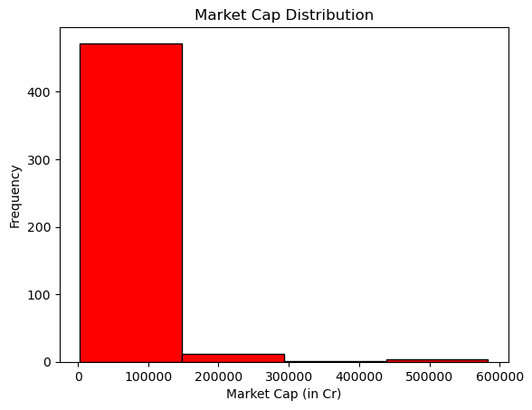

```python
plt.hist(dataFrame['Market Cap (in Cr)'], bins = 4, color = 'red', edgecolor = 'black')
plt.xlabel('Market Cap (in Cr)')
plt.ylabel('Frequency')
plt.title('Market Cap Distribution')
plt.show()
```

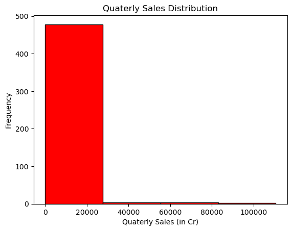

```python
plt.hist(dataFrame['Quaterly Sales (in Cr)'], bins = 4, color = 'red', edgecolor = 'black')
plt.xlabel('Quaterly Sales (in Cr)')
plt.ylabel('Frequency')
plt.title('Quaterly Sales Distribution')
plt.show()
```

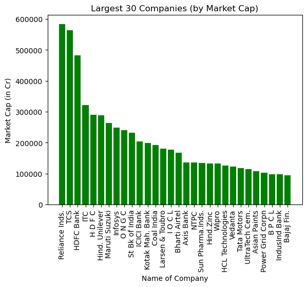

```python
x = largest_mk_cap_comp['Name of Company'].head(30)
y = largest_mk_cap_comp['Market Cap (in Cr)'].head(30)
plt.bar(x, y, color = 'green')
plt.xticks(x, rotation = 'vertical')
plt.xlabel('Name of Company')
plt.ylabel('Market Cap (in Cr)')
plt.title('Largest 30 Companies (by Market Cap)')
plt.show()
```

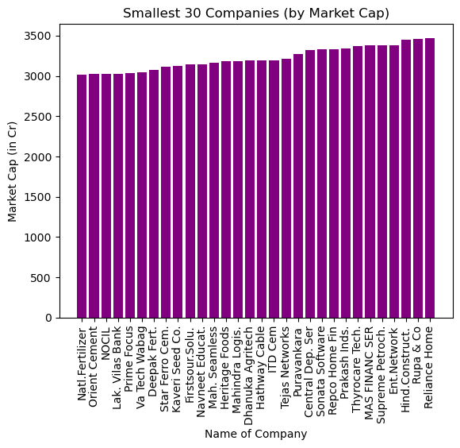

```python
x = smallest_mk_cap_comp['Name of Company'].head(30)
y = smallest_mk_cap_comp['Market Cap (in Cr)'].head(30)
plt.bar(x, y, color = 'purple')
plt.xticks(x, rotation = 'vertical')
plt.xlabel('Name of Company')
plt.ylabel('Market Cap (in Cr)')
plt.title('Smallest 30 Companies (by Market Cap)')
plt.show()
```

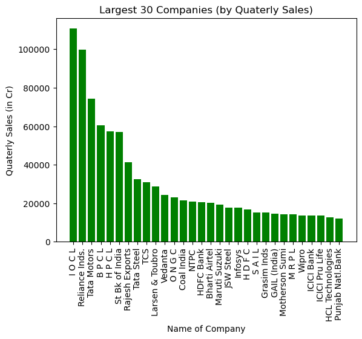

```python
x = largest_qt_sales_comp['Name of Company'].head(30)
y = largest_qt_sales_comp['Quaterly Sales (in Cr)'].head(30)
plt.bar(x, y, color = 'green')
plt.xticks(x, rotation = 'vertical')
plt.xlabel('Name of Company')
plt.ylabel('Quaterly Sales (in Cr)')
plt.title('Largest 30 Companies (by Quaterly Sales)')
plt.show()
```

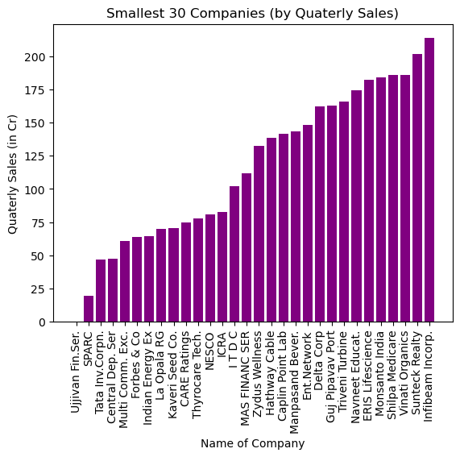

```python
x = smallest_qt_sales_comp['Name of Company'].head(30)
y = smallest_qt_sales_comp['Quaterly Sales (in Cr)'].head(30)
plt.bar(x, y, color = 'purple')
plt.xticks(x, rotation = 'vertical')
plt.xlabel('Name of Company')
plt.ylabel('Quaterly Sales (in Cr)')
plt.title('Smallest 30 Companies (by Quaterly Sales)')
plt.show()
```

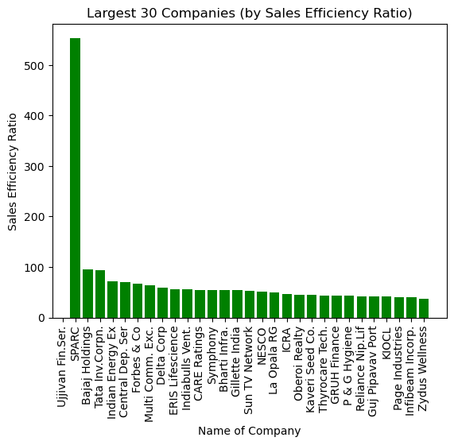

```python
x = largest_sales_eff_ratio_comp['Name of Company'].head(30)
y = largest_sales_eff_ratio_comp['Sales Efficiency Ratio'].head(30)
plt.bar(x, y, color = 'green')
plt.xticks(x, rotation = 'vertical')
plt.xlabel('Name of Company')
plt.ylabel('Sales Efficiency Ratio')
plt.title('Largest 30 Companies (by Sales Efficiency Ratio)')
plt.show()
```

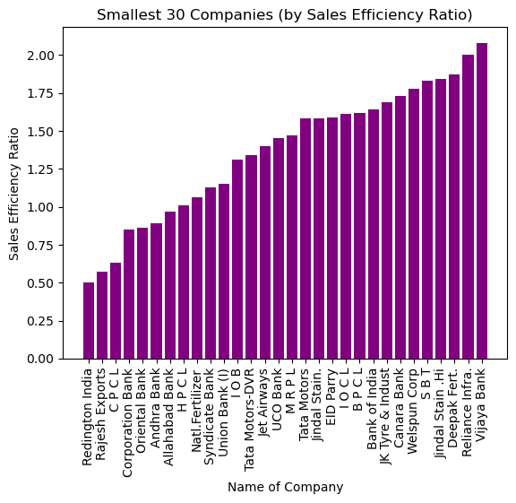

```python
x = smallest_sales_eff_ratio_comp['Name of Company'].head(30)
y = smallest_sales_eff_ratio_comp['Sales Efficiency Ratio'].head(30)
plt.bar(x, y, color = 'purple')
plt.xticks(x, rotation = 'vertical')
plt.xlabel('Name of Company')
plt.ylabel('Sales Efficiency Ratio')
plt.title('Smallest 30 Companies (by Sales Efficiency Ratio)')
plt.show()
```

# Insights

1)Reliance Industries (5,83,436 Cr) has the biggest market cap share

2)Natl. Fertilizers (3,017 Cr) has the smallest market share

3)IOCL (1,10,666 Cr) has most quaterly sales

4)Ujjivan Financial Services (0 Cr) has least quaterly sales

5)SPARC (553.82) has the highest Sales Efficiency Ratio

7)Majority companies market cap lies between between 0 - 1,50,000 Cr

8)Majority companies quaterly sales lies between 0 - 27,500 Cr

# Conclusion

The majority of companies fall within certain ranges of market capitalization and quarterly sales, indicating the typical distribution in the market

Overall, these insights provide a snapshot of the market dynamics and the performance of different companies within it